# Aesthetics and Visualizations Using Hotel Booking Dataset

Keman Xiang

## Background for this activity

In this notebook, we’ll review a scenario, and continue to apply our knowledge of data visualization with ggplot2. we will apply the aesthetic features of visualizations and customize them by specific criteria.

## The Scenario

In this notebook, we are junior data analysts working for the same hotel booking company from earlier. Last time, we created some simple visualizations with `ggplot2` to give our stakeholders quick insights into our data. Now, we are are interested in creating visualizations that highlight different aspects of the data to present to our stakeholder. we are going to expand on `ggplot2` and create new kinds of visualizations like bar charts.

## Step 1: Import our data

The data in this example is originally from the article Hotel Booking Demand Datasets (https://www.sciencedirect.com/science/article/pii/S2352340918315191), written by Nuno Antonio, Ana Almeida, and Luis Nunes for Data in Brief, Volume 22, February 2019.

The data was downloaded and cleaned by Thomas Mock and Antoine Bichat for #TidyTuesday during the week of February 11th, 2020 (https://github.com/rfordatascience/tidytuesday/blob/master/data/2020/2020-02-11/readme.md).

we can learn more about the dataset here: https://www.kaggle.com/jessemostipak/hotel-booking-demand

Read in the file ‘hotel_bookings.csv’ into a data frame:

```r
hotel_bookings <- read.csv("hotel_bookings.csv")
```

## Step 2: Refresh our Memory

By now, we are pretty familiar with this data set. But we can refresh our memory with the `head()` and `colnames()` functions.

```r
head(hotel_bookings)
```

```
##          hotel is_canceled lead_time arrival_date_year arrival_date_month
## 1 Resort Hotel           0       342              2015               July
## 2 Resort Hotel           0       737              2015               July
## 3 Resort Hotel           0         7              2015               July
## 4 Resort Hotel           0        13              2015               July
## 5 Resort Hotel           0        14              2015               July
## 6 Resort Hotel           0        14              2015               July
##   arrival_date_week_number arrival_date_day_of_month stays_in_weekend_nights
## 1                       27                         1                       0
## 2                       27                         1                       0
## 3                       27                         1                       0
## 4                       27                         1                       0
## 5                       27                         1                       0
## 6                       27                         1                       0
##   stays_in_week_nights adults children babies meal country market_segment
```

[output cut: 41 more lines]

```r
colnames(hotel_bookings)
```

```
##  [1] "hotel"                          "is_canceled"
##  [3] "lead_time"                      "arrival_date_year"
##  [5] "arrival_date_month"             "arrival_date_week_number"
##  [7] "arrival_date_day_of_month"      "stays_in_weekend_nights"
##  [9] "stays_in_week_nights"           "adults"
## [11] "children"                       "babies"
## [13] "meal"                           "country"
## [15] "market_segment"                 "distribution_channel"
## [17] "is_repeated_guest"              "previous_cancellations"
## [19] "previous_bookings_not_canceled" "reserved_room_type"
## [21] "assigned_room_type"             "booking_changes"
## [23] "deposit_type"                   "agent"
## [25] "company"                        "days_in_waiting_list"
## [27] "customer_type"                  "adr"
## [29] "required_car_parking_spaces"    "total_of_special_requests"
## [31] "reservation_status"             "reservation_status_date"
```

## Step 4: Making a Bar Chart

Previously in my last notebook, we used `geom_point` to make a scatter plot comparing lead time and number of children. Now, we will use `geom_bar` to make a bar chart:

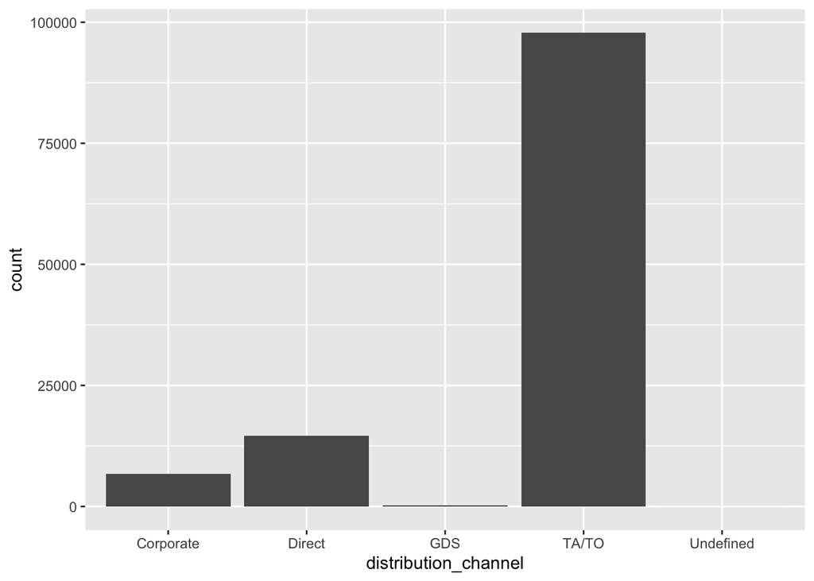

```r
ggplot(data = hotel_bookings) +
  geom_bar(mapping = aes(x = distribution_channel))
```

## Insight

What distribution type has the most number of bookings? The TA/TO distribution type has the most number of bookings.

## Step 5: Diving deeper into bar charts

After exploring our bar chart, our stakeholder has more questions. Now they want to know if the number of bookings for each distribution type is different depending on whether or not there was a deposit or what market segment they represent.

We will use ‘fill=deposit_type’ to accomplish this.

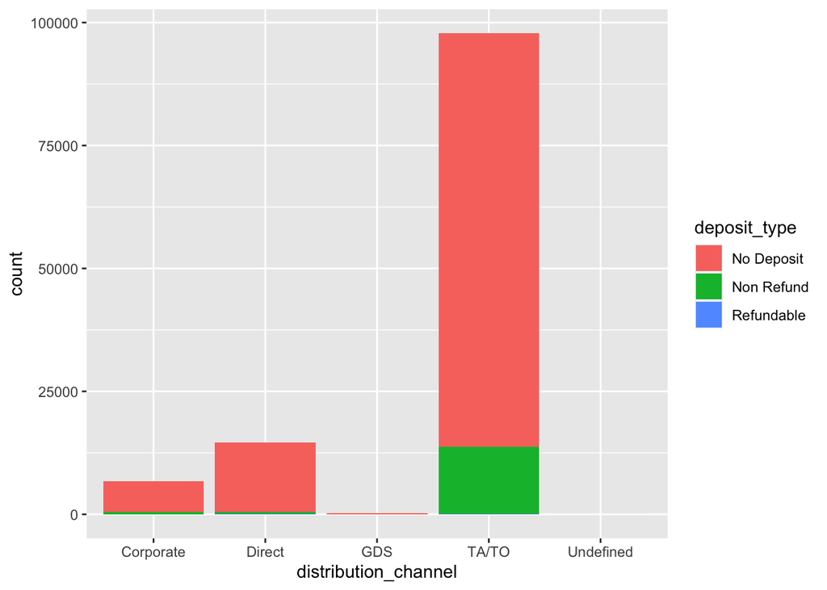

Now answering the question about different market segments. We will use ‘fill=market_segment’ to accomplish this.

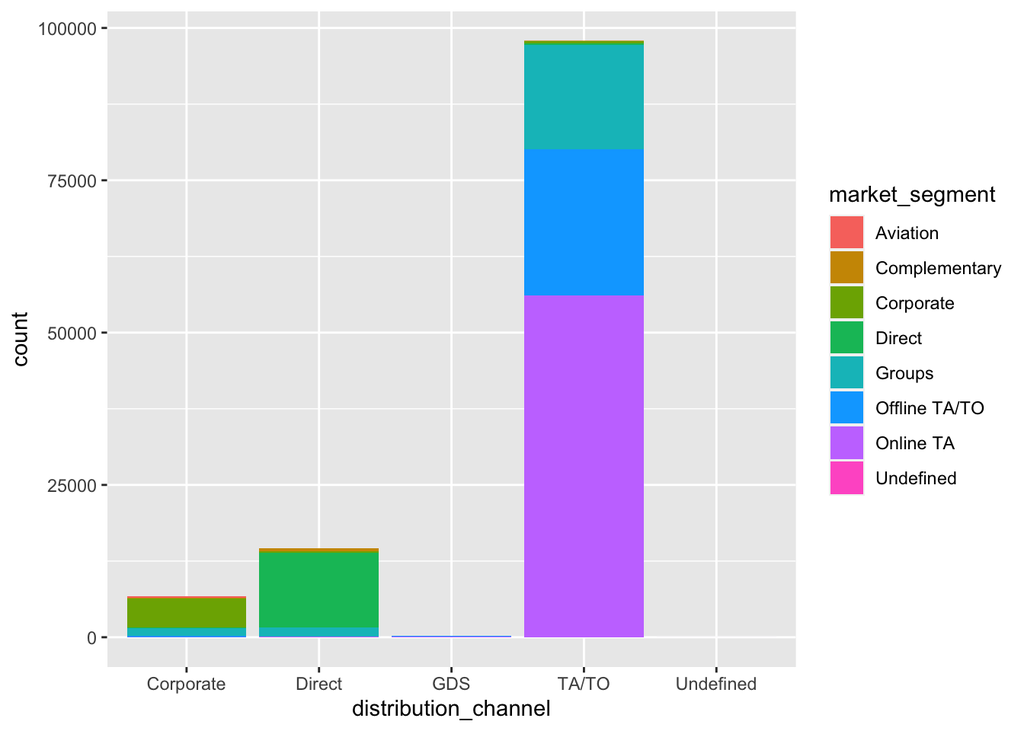

## Step 6: Facets galore

After reviewing the new charts, our stakeholder asks us to create separate charts for each deposit type and market segment to help them understand the differences more clearly.

Create a different chart for each deposit type:

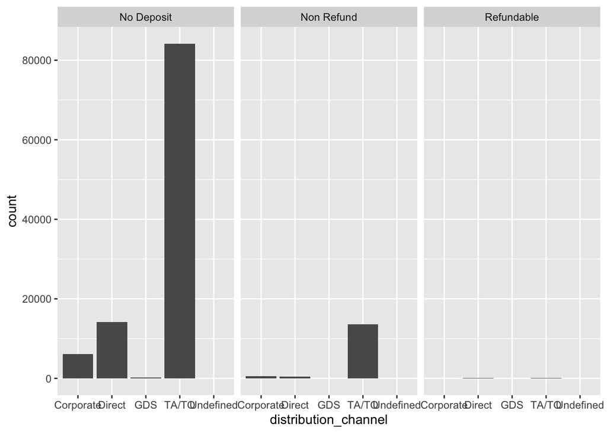

```r
ggplot(data = hotel_bookings) +
  geom_bar(mapping = aes(x = distribution_channel)) +
  facet_wrap(~deposit_type)
```

Create a different chart for each market segment:

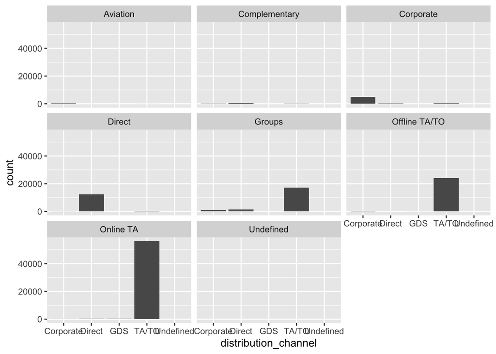

```r
ggplot(data = hotel_bookings) +
  geom_bar(mapping = aes(x = distribution_channel)) +
  facet_wrap(~market_segment)
```

The `facet_grid` function does something similar. The main difference is that `facet_grid` will include plots even if they are empty.

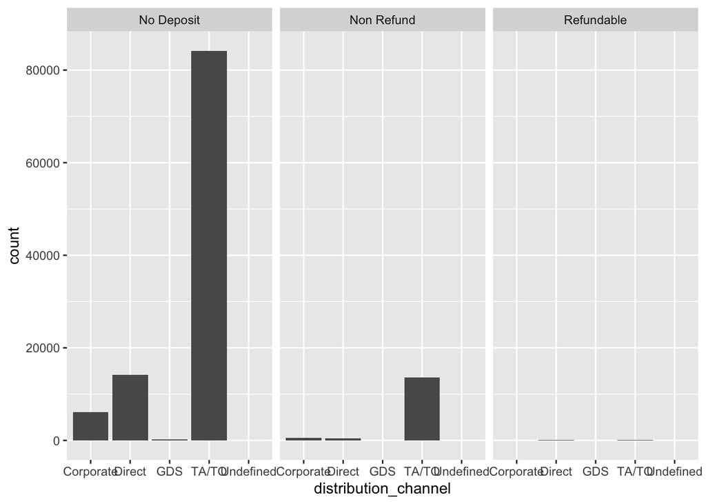

```r
ggplot(data = hotel_bookings) +
  geom_bar(mapping = aes(x = distribution_channel)) +
  facet_grid(~deposit_type)
```

Now, we could put all of this in one chart and explore the differences by deposit type and market segment.

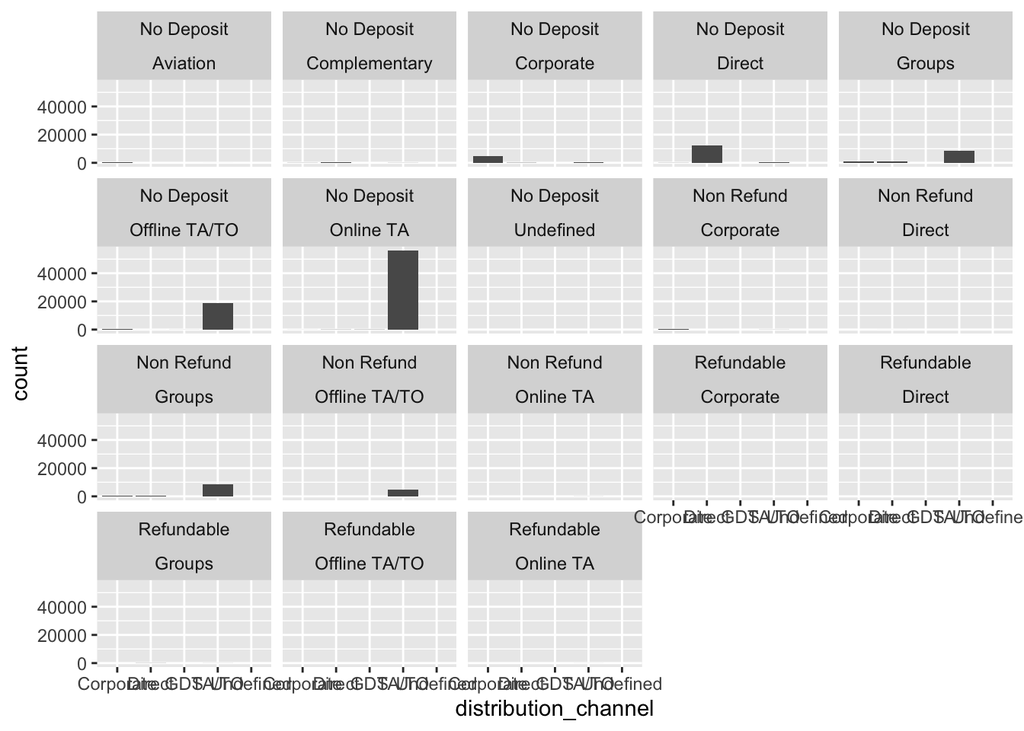

```r
ggplot(data = hotel_bookings) +
  geom_bar(mapping = aes(x = distribution_channel)) +
  facet_wrap(~deposit_type~market_segment)
```

These charts are probably overwhelming and too hard to read, but it can be useful if we are exploring our data through visualizations.

## Wrap Up

The `ggplot2` package allows we to create a variety of visualizations in `R`, from simple scatter plots to complicated, multi-faceted bar charts.